# GROUP1_DMV

## Distribution of Depressed Students Across Gender

- The barplot shows that more female student are depressed than the male students. it could show that in this dataset the female are more emotional.

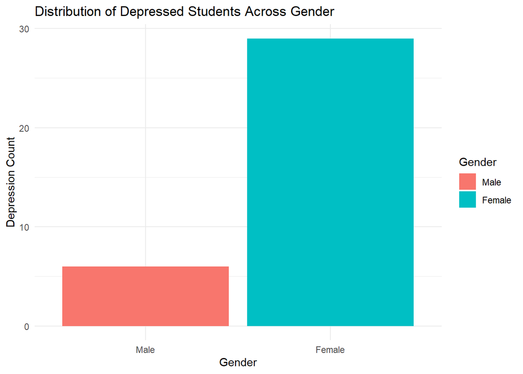

```r
ggplot(data = data_depressed, aes(x = Gender, fill = Gender)) +
  geom_bar() +
  labs(title = "Distribution of Depressed Students Across Gender", x = "Gender", y = "Depression Count") +
  theme_minimal()
```

## Number of Students Who Seek Treatment - this indicates that even tough students are depressed and have mental health issue they dont seek aany kond of professional treatment that can help them

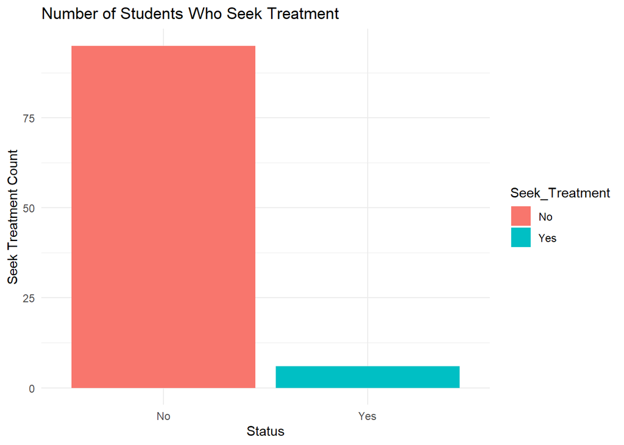

```r
ggplot(data = data, aes(x = Seek_Treatment , fill = Seek_Treatment )) +
  geom_bar() +
  labs(title = "Number of Students Who Seek Treatment", x = "Status", y = "Seek Treatment Count") +
  theme_minimal()
```

## Distribution of Depressed Students Across Status - the ditribution in the barplot conludes that the married students are less depressed due to possible support system from their spouse. the married students are also mentally more stable because of the more experience in handling emotion towards their spouse than the unmarried one

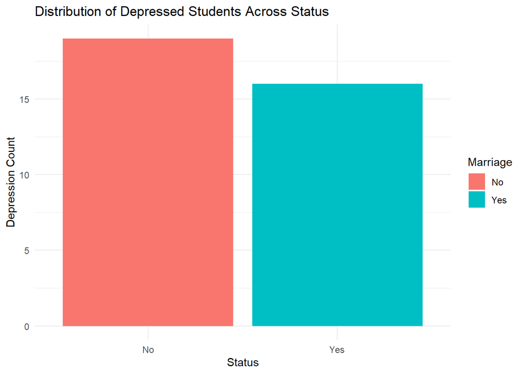

```r
ggplot(data = data_depressed, aes(x = Marriage, fill = Marriage)) +
  geom_bar() +
  labs(title = "Distribution of Depressed Students Across Status", x = "Status", y = "Depression Count") +
  theme_minimal()
```

## Association between Year of Study and Depression (Normalized)

```r
# Create a contingency table
cont_table <- table(data$Year_Study, data$Depression)

# Normalize the contingency table
normalized_cont_table <- prop.table(cont_table, margin=1)

normalized_cont_table
```

```
##
##             No       Yes
##    1 0.6744186 0.3255814
##    2 0.6153846 0.3846154
##    3 0.5833333 0.4166667
##    4 0.8750000 0.1250000
```

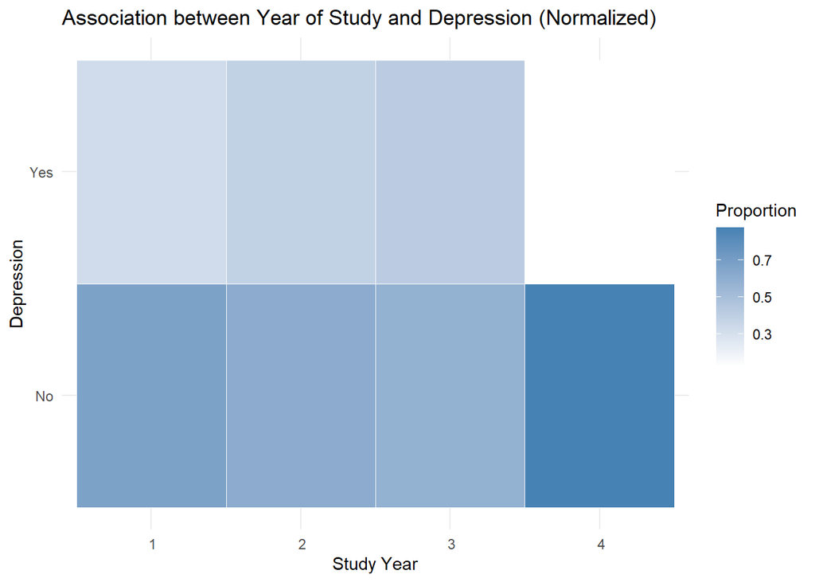

```r
# Convert the normalized contingency table to a data frame
cont_df <- as.data.frame.table(normalized_cont_table)

# Create a ggplot correlation plot using normalized data
ggplot(cont_df, aes(x = Var1, y = Var2, fill = Freq)) +
  geom_tile(color = "white") +
  scale_fill_gradient(low = "white", high = "steelblue", na.value = "white") +
  theme_minimal() +
  labs(x = "Study Year", y = "Depression", fill = "Proportion") +
  ggtitle("Association between Year of Study and Depression (Normalized)")
```

## CONCLUSION

The data analysis reveals that students are facing mental health struggles collectively grouped by their age and gender.

We can see that in the the age of 20-22, students are facing less mental issues. Whereas, in the age of 18-19 and 23 or above they face many more challenges as they are enrolling to a new stage in their life during those age.

The data also reveals that female students are more prone to mental health issues as they are more sensitive and delicate towards their feelings and their thoughts.

==================================================================================

## Recommendation

The data of student mental health gives us a clear picture of how students struggle mentally in their college life. With their own personal conditions such as their age, gender, year of study, major and marietal status can affect their mental health conditions significantly. This data can be a reference to student advisory centers because most of the students are still refusing to seek for treatments. Because in our society, people mostly consider seeking for mental treatments or going to a psychiatrist as some kind of a negative sign or some kind of a taboo.

We must be more open-minded and take mental health seriously. Because an individual’s mental health can cause them to do various things according to their own mental health.

Give more support to the students who are currently in the phase of hard times mentally. If we are facing the issue ourselves we don’t need to be ashamed to seek for professional treatments, and also we must seek for a group of positive people around us.

Furthermore, for the people who are just about to attend college, make sure we choose the major that is suitable with our interests. Therefore, we may decline the possibilities of being depressed that is caused by difficulties in our major.

For further research, we suggest a more balanced distribution of data base between various age, gender and year of study to ensure a better quality of data.

At last but not least, prioritizing mental health conditions, and conducting comprehensive analyses are essential steps toward fostering a culture of mental wellness within educational institutions.